# Звіт до лабораторної роботи №3

## з предмету "Моделі інтелектуальних систем"

### Дровольського Ярослава, ІПС-42

### Варіант №2

Install pandas for Jupyter Notebook environment

```python
!pip install pandas
```

[output not shown]

Install matplotlib for Jupyter Notebook environment to make plots

```python
!pip install matplotlib
```

[output not shown]

[output cut: 165 more lines]

[output not shown]

Import pandas

```python
import pandas as pd
```

Обрахунок номеру варіанта:

```python
n = 2
print((n + 4) % 5 + 1)
```

```
2
```

Далі було завантажено набір даних про дитячі імена в США за [посиланням](https://www.kaggle.com/datasets/kaggle/us-baby-names)

Читаємо CSV-файл у DataFrame:

```python
df = pd.read_csv('NationalNames.csv')
```

Подивимося на загальний вигляд таблиці. Бачимо, що в ньому вказана популярність імен в кожен рік з 1880 по 2014.

```python
df
```

|  | Id | Name | Year | Gender | Count |
| --- | --- | --- | --- | --- | --- |
| 0 | 1 | Mary | 1880 | F | 7065 |
| 1 | 2 | Anna | 1880 | F | 2604 |
| 2 | 3 | Emma | 1880 | F | 2003 |
| 3 | 4 | Elizabeth | 1880 | F | 1939 |
| 4 | 5 | Minnie | 1880 | F | 1746 |
| ... | ... | ... | ... | ... | ... |
| 1825428 | 1825429 | Zykeem | 2014 | M | 5 |
| 1825429 | 1825430 | Zymeer | 2014 | M | 5 |
| 1825430 | 1825431 | Zymiere | 2014 | M | 5 |
| 1825431 | 1825432 | Zyran | 2014 | M | 5 |
| 1825432 | 1825433 | Zyrin | 2014 | M | 5 |

1825433 rows × 5 columns

### Вправа 3

Отримайте імена стовпців набору даних.

```python
df.columns
```

```
Index(['Id', 'Name', 'Year', 'Gender', 'Count'], dtype='object')
```

### Вправа 4

Отримайте загальну інформацію про дані у наборі даних.

```python
df.describe()
```

|  | Id | Year | Count |
| --- | --- | --- | --- |
| count | 1.825433e+06 | 1.825433e+06 | 1.825433e+06 |
| mean | 9.127170e+05 | 1.972620e+03 | 1.846879e+02 |
| std | 5.269573e+05 | 3.352891e+01 | 1.566711e+03 |
| min | 1.000000e+00 | 1.880000e+03 | 5.000000e+00 |
| 25% | 4.563590e+05 | 1.949000e+03 | 7.000000e+00 |
| 50% | 9.127170e+05 | 1.982000e+03 | 1.200000e+01 |
| 75% | 1.369075e+06 | 2.001000e+03 | 3.200000e+01 |
| max | 1.825433e+06 | 2.014000e+03 | 9.968000e+04 |

### Вправа 5

Знайдіть кількість унікальних імен у наборі даних

```python
df['Name'].nunique()
```

```
93889
```

### Вправа 8

Знайдіть найпопулярніше ім’я за результатами одного року (ім’я, для якого Count максимальне)

```python
def task_8(year):
    # print selected part of dataframe
    df_for_year = df[df.Year == year]
    print(df_for_year)

    row_index = df_for_year['Count'].idxmax() # .idxmax() returns label index of row where max value of 'Count' column is situated
    row = df.loc[[ row_index]]
    name = df.at[row_index, 'Name']
    print("\n\nLabel-based index of row: " + str(row_index))
    print("\nRow: \n" + str(row))
#    print("\nThe name: \'" + str(name) + "\' in ")
    print(f"\nThe name is '{name}' in {year}")

task_8(1947)
```

```
            Id      Name  Year Gender  Count
431052  431053     Linda  1947      F  99680
431053  431054      Mary  1947      F  71684
431054  431055  Patricia  1947      F  51273
431055  431056   Barbara  1947      F  48793
431056  431057    Sandra  1947      F  34770
...        ...       ...   ...    ...    ...
441419  441420  Zacarias  1947      M      5
441420  441421       Zan  1947      M      5
441421  441422    Zannie  1947      M      5
441422  441423    Zebbie  1947      M      5
441423  441424      Zell  1947      M      5

[10372 rows x 5 columns]


Label-based index of row: 431052

Row:
            Id   Name  Year Gender  Count
431052  431053  Linda  1947      F  99680

The name is 'Linda' in 1947
```

### Вправа 9

Підрахуйте кількість записів, для яких Count - мінімальне у наборі.

```python
def task_9():
    count_column = df['Count']
    count_min = count_column.min()
    result = count_column[count_column == count_min].size
    print(result)

task_9()
```

```
254615
```

### Вправа 11

Знайдіть рік із найбільшою кількістю унікальних імен.

```python
def get_names_for_year(year):
    return df[df.Year == year]['Name']

def task_11():
    years = df['Year'].unique() # get array of years

    # create dataframe with two columns: {Year}, {Number of unique names in year}
    df_unique_names = pd.DataFrame(data = [{'Year': year, 'Name': get_names_for_year(year).nunique()} for year in years],
                                  index = years)

    row_index = df_unique_names['Name'].idxmax()
    print(df_unique_names.loc[[ row_index]])


task_11()
```

```
      Year   Name
2008  2008  32488
```

### Вправа 12

Знайдіть найпопулярніше ім’я в році з найбільшою кількістю унікальних імен (тобто у 2008 році)

```python
def task_12(year):
    row_index = df[df.Year == year]['Count'].idxmax()
    name = df.at[row_index, 'Name']
    print(f"'{name}'")

task_12(2008)
```

```
'Jacob'
```

### Вправа 13

Знайдіть рік, коли ім’я “Jacob” було найпопулярнішим серед жіночих імен

Зважаючи на очікуваний результат (у методичці), умову можна переформулювати так: "Знайдіть рік, коли жіноче ім'я “Jacob” мало максимальну популярність".

```python
def task_13(name, gender):
    row_index = df[(df.Name == name) & (df.Gender == gender)]['Count'].idxmax()
    print(df.loc[[ row_index]])

task_13('Jacob', 'F')
```

```
              Id   Name  Year Gender  Count
1455556  1455557  Jacob  2004      F    171
```

### Вправа 14

Знайти рік із найбільшою кількістю гендерно нейтральних імен (однакові чоловічі та жіночі імена)

```python
import numpy as np

def get_all_gender_unique_names(gender):
    return df[df.Gender == gender]['Name'].unique() # returns NumPy array

def get_unique_names_for_year(year):
    return df[df.Year == year]['Name'].unique()

def get_gender_neutral_names_for_year(year):
    male_names = df[(df.Year == year) & (df.Gender == 'M')]['Name'].to_numpy()
    female_names = df[(df.Year == year) & (df.Gender == 'F')]['Name'].to_numpy()
    return np.intersect1d(male_names, female_names)


def task_14():
    years = df['Year'].unique() # get array with years

    # create dataframe with two columns: {year}, {number of gender neutral names in this year}
    df_gender_neutral_names = pd.DataFrame(data = [{'Year': year,
                                                    'Gender_neutral_names': get_gender_neutral_names_for_year(year).size} for year in years],
                                  index = years)

    row_index = df_gender_neutral_names['Gender_neutral_names'].idxmax()

    print(df_gender_neutral_names.loc[[ row_index]])


task_14()
```

```
      Year  Gender_neutral_names
2008  2008                  2557
```

### Вправа 16

Знайдіть рік, коли народилося найбільше дітей

```python
def get_number_of_people_for_year(year):
    return df[df.Year == year]['Count'].sum()

def task_16():
    years = df['Year'].unique() # get array with years

    # create dataframe with two columns: {year}, {number of people born in this year}
    df_count = pd.DataFrame(data = [{'Year': year, 'Count': get_number_of_people_for_year(year)} for year in years],
                                  index = years)

    row_index = df_count['Count'].idxmax()

#    print(df_count.loc[[ row_index]])
    print(df_count.at[row_index, 'Year'])

task_16()
```

```
1957
```

### Вправа 17

Знайдіть кількість дівчаток та хлопчиків, які народились кожного року

```python
def get_number_of_gender_for_year(year, gender):
    return df[(df.Year == year) & (df.Gender == gender)]['Count'].sum()

def task_17():
    years = df['Year'].unique() # get array with years

    # create dataframe with three columns: {year}, {number of Female}, {number of Male}
    df_genders = pd.DataFrame(data = [{'Year': year, 'F': get_number_of_gender_for_year(year, 'F'),
                                     'M': get_number_of_gender_for_year(year, 'M')} for year in years],
                                  index = years)

    return df_genders

df_genders = task_17()
df_genders
```

|  | Year | F | M |
| --- | --- | --- | --- |
| 1880 | 1880 | 90993 | 110491 |
| 1881 | 1881 | 91954 | 100745 |
| 1882 | 1882 | 107850 | 113688 |
| 1883 | 1883 | 112321 | 104629 |
| 1884 | 1884 | 129022 | 114445 |
| ... | ... | ... | ... |
| 2010 | 2010 | 1772738 | 1913851 |
| 2011 | 2011 | 1753500 | 1893230 |
| 2012 | 2012 | 1753922 | 1889414 |
| 2013 | 2013 | 1745339 | 1881463 |
| 2014 | 2014 | 1768775 | 1901376 |

135 rows × 3 columns

### Вправа 18

Підрахуйте кількість років, коли дівчаток народжувалось більше, ніж хлопчиків.

```python
df_female_more_male = df_genders[df_genders.F > df_genders.M]
len(df_female_more_male.index)
```

```
54
```

### Вправа 19

Накресліть графік загальної кількості народжень хлопчиків та дівчаток на рік.

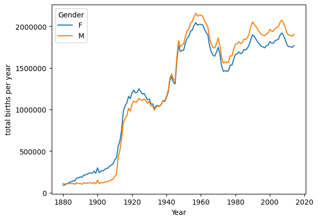

```python
# for successful work, task_17 should be executed first

import matplotlib.pyplot as plt
import matplotlib.ticker as ticker

g = df_genders.plot(y=['F', 'M'], xlabel='Year', ylabel='total births per year')

# add legent title
g.legend(title='Gender')

# format ticks on Y axis
formatter = ticker.ScalarFormatter()
formatter.set_scientific(False)
g.yaxis.set_major_formatter(formatter)

plt.show()
```

### Вправа 20

Підрахуйте кількість гендерно-нейтральних імен (однакових для дівчат та хлопців)

```python
import numpy as np

def get_gender_names(gender):
    return df[df.Gender == gender]['Name'].unique()

def task_20():
    male_names = get_gender_names('M')
    female_names = get_gender_names('F')
    return np.intersect1d(male_names, female_names).size

task_20()
```

```
10221
```

### Вправа 22

Підрахуйте скільки років проводилось спостереження

```python
def task_22():
    n_years = df['Year'].nunique()
    print(f"'Спостереження проводилось {n_years} років'")

task_22()
```

```
'Спостереження проводилось 135 років'
```

### Вправа 23

Знати найпопулярніші гендерно-нейтральні імена (ті, що присутні кожного року)

```python
def get_gender_names(gender):
    return df[df.Gender == gender]['Name'].unique()

def get_gender_neutral_names():
    male_names = get_gender_names('M')
    female_names = get_gender_names('F')
    return np.intersect1d(male_names, female_names)

def task_23():
    neutral_names = get_gender_neutral_names()
    number_of_years = df['Year'].nunique()

    # dataframe for neutral names
    df_neutral_names = df[df.Name.isin(neutral_names)]

    # dataframe: for each name it is number of occurrences (years) wher it is present.
    # (Note that if the same name is present in same year twice (because of M and F genders), it will be counted twice)
    df_neutral_names_count_years = df_neutral_names.groupby("Name")['Year'].count()

    # Get names that we need by task. Name must be occured twice (for M and F genders, hence we need neutral names) for each year
    result_names = df_neutral_names_count_years[df_neutral_names_count_years == 2*number_of_years].index.values

    # calculate number of overall count for each result name
    df_result_names = df[df.Name.isin(result_names)]
    result_names_counts = df_result_names.groupby("Name")['Count'].sum()

    print(result_names_counts.sort_values(ascending=False))


task_23()
```

```
Name
James      5129096
John       5106590
Robert     4816785
William    4071368
Joseph     2580687
Jean        480901
Jesse       421406
Leslie      376587
Francis     312147
Lee         291691
Jessie      274931
Marion      259549
Johnnie     149953
Sidney      105185
Ollie        56482
Tommie       51315
Name: Count, dtype: int64
```

### Вправа 24

Знайти найпопулярніше серед непопулярних імен (непопулярне ім’я, яким називали дітей найбільшу кількість разі

Знайти ім'я, що мають найбільший Count серед імен, що використані у найменшій кількості років)

```python
def task_24():
    # create series with number of years specific name was used for each name
    df_names_years_count = df.groupby("Name")['Year'].count()
    min_year_count = df_names_years_count.min()

    # list of names that used in min number of years
    unpopular_names = df_names_years_count[df_names_years_count == min_year_count].index.values

    # get Count for each unpopular name
    df_unpopular_names = df[df.Name.isin(unpopular_names)]
    popular_unpopular_names = df_unpopular_names.groupby("Name")['Count'].sum()

    # get the most popular from unpopular names
    max_count = popular_unpopular_names.max()
    most_popular_unpopular_names = popular_unpopular_names[popular_unpopular_names == max_count]

    name = most_popular_unpopular_names.index[0]
    count = most_popular_unpopular_names.values[0]
    print(f"The most popular name from unpopular ones is '{name}'. It were used {count} times")

task_24()
```

```
The most popular name from unpopular ones is 'Christop'. It were used 1082 times
```

### Вправа 27

Знайти найпопулярніші імена в кожному році.

```python
def find_popular_name_in_year(year):
    df_year = df[df.Year == year]
    index_max = df_year['Count'].idxmax()
    return [df_year.at[index_max, 'Name'], df_year.at[index_max, 'Count']]

def task_27():
    years = df['Year'].unique() # get array with years

    # create dataframe with three columns: {year}, {the most popular name in this year}, {count of this name}
    df_popular_names_in_year = pd.DataFrame(data = [{'Year': year, 'Name': find_popular_name_in_year(year)[0],
                                     'Count': find_popular_name_in_year(year)[1]} for year in years],
                                  index = years)

    return df_popular_names_in_year

task_27()
```

|  | Year | Name | Count |
| --- | --- | --- | --- |
| 1880 | 1880 | John | 9655 |
| 1881 | 1881 | John | 8769 |
| 1882 | 1882 | John | 9557 |
| 1883 | 1883 | John | 8894 |
| 1884 | 1884 | John | 9388 |
| ... | ... | ... | ... |
| 2010 | 2010 | Isabella | 22883 |
| 2011 | 2011 | Sophia | 21816 |
| 2012 | 2012 | Sophia | 22267 |
| 2013 | 2013 | Sophia | 21147 |
| 2014 | 2014 | Emma | 20799 |

135 rows × 3 columns